# A history of rationality in economics

A computational approach

Thomas Delcey

Thomas.delcey@ube.fr

Université de Bourgogne

Aurélien Goutsmedt

aurelien.goutsmedt@uclouvain.be

UC Louvain; ICHEC

Alexandre Truc

Alexandre.truc@cnrs.fr

CNRS, Université Côte d’Azur

## Context

- **Special issue**: methods in the history of economic thought (HET) ;
- **Objective**: write a methodological essay showing how quantitative tools can enrich history of economic thought ;

Neither a proof of concept paper, nor a review of methods

## Our contribution

- Using textual methods to capture the evolving usages and meanings of rationality:
  - A long-standing concern for historians of economics ;
  - A complex and evolving concept ;
- Build a method to:
  - explore very large of corpora (millions of sentences) ;
  - taking into account historical context ;
  - discuss concretely the challenges at each step.

## From sources to corpus

- Our main source: JSTOR fulltext database (around 300 000 documents, 31 millions sentences) + elsevier and istex’s fulltext + econlit’s abstracts + wos’ citation data.

**With textual data, it is often more challenging to build the data than to analyze it:**

- Access to the source.
- Filtering documents (book reviews).
- Cleaning texts (headers, acknowledgements, etc.).
- Matching datasets.
- Handling large datasets.

## Corpus distribution

Figure 1: Distribution of documents in the JSTOR fulltext database

(a) Année de publication

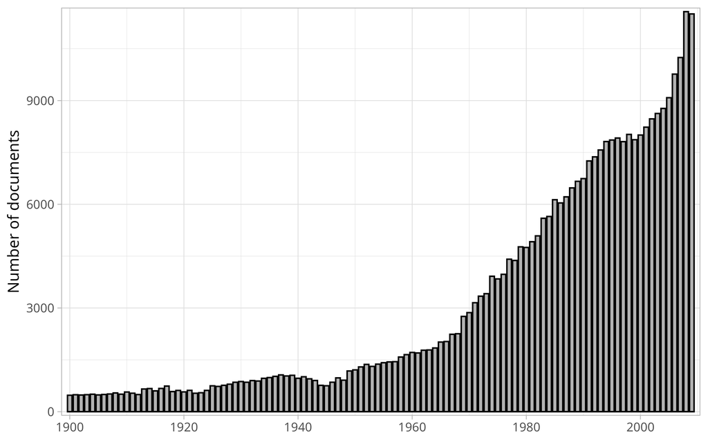

(b) Language

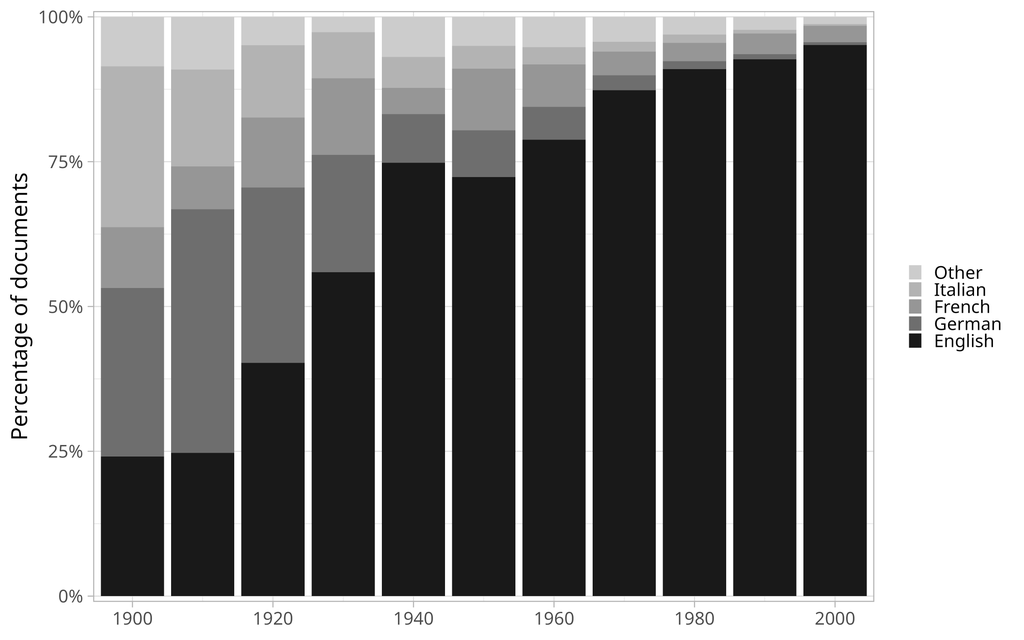

## Descriptive exploration

Figure 2: Exploration of the corpus with simple text analysis tools

(a) Term frequency

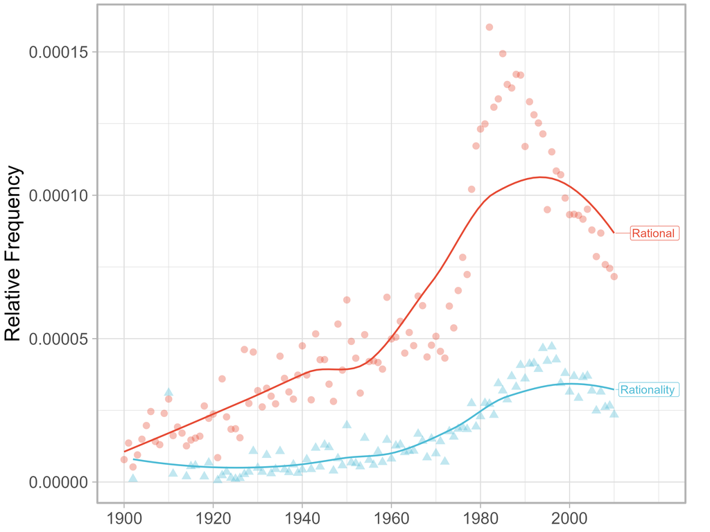

(b) Neighbor words of “rational” and “rationality”

[figure not shown]

## Which methods?

Figure 3: Illustrations of probablistic topic model outputs in HET

(a) A probabilistic topic model

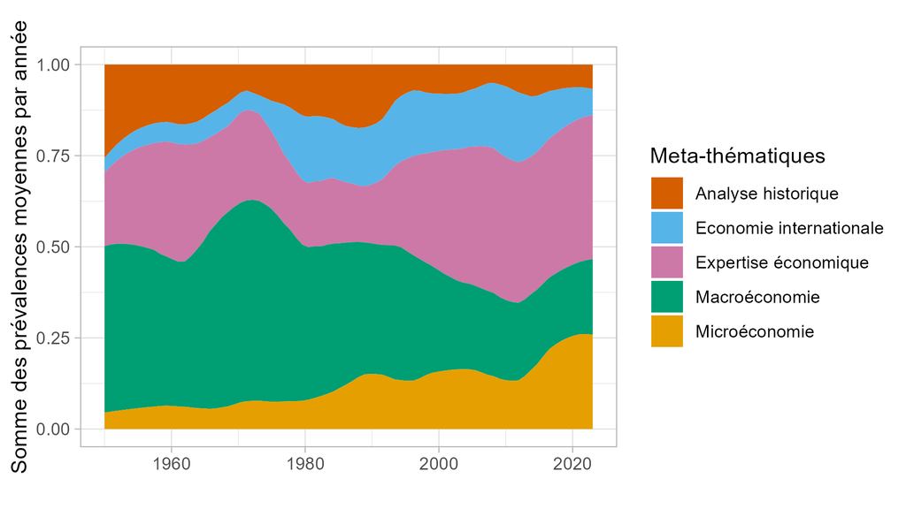

(b) Inference from topics

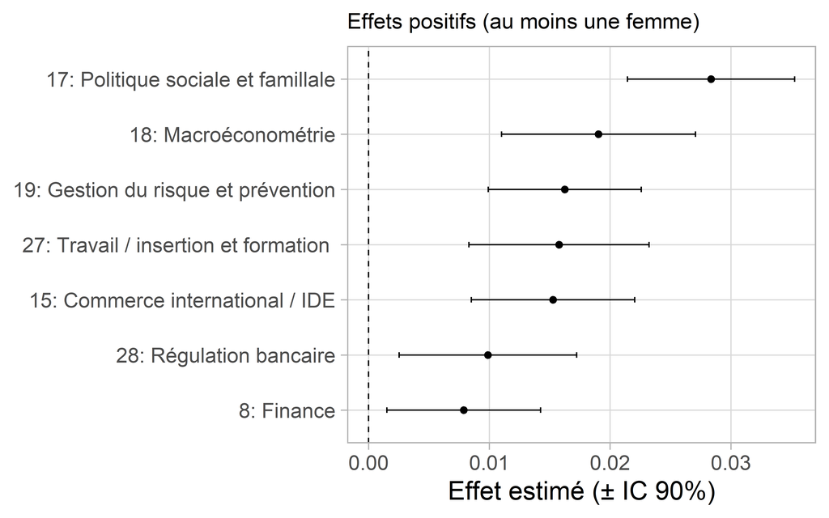

## Representing a text

Table 1: Exemple de corpus en format tidy

| id | text | is_funded_by_industry | year | variable_4 |
| --- | --- | --- | --- | --- |
| 1 | I love markets | yes | 1950 | ... |
| 2 | Viva la revolucion | no | 1950 | ... |
| 3 | In markets, we trust | yes | 1955 | ... |
| ... | ... | ... | ... | ... |

For human eyes, it is easy to spot that first and third documents are semantically closer than second one. How a computer can spot it ?

## Bag-of-words

- The simplest method is to count the frequency of the chosen textual units (words, n-gram, etc.) in each document.

**Bag-of-words**

- Given a corpus $C$ with $D$ documents.
- And a vocabulary $V$ termes, la liste des mots uniques du corpus.
- The bag-of-words representation of $C$ is a matrix $W$ of dimension $D \times V$.
- Each entry $w_{d,v}$ is the number of occurrences of term $v$, $v \in \{1, \ldots, V\}$ in document $d$, $d \in \{1, \ldots, D\}$.

## An example

Table 2: Exemple de corpus en format tidy

| id | text | is_funded_by_industry | year | variable_4 |
| --- | --- | --- | --- | --- |
| 1 | I love markets | yes | 1950 | ... |
| 2 | Viva la revolucion | no | 1950 | ... |
| 3 | In markets, we trust | yes | 1955 | ... |
| ... | ... | ... | ... | ... |

Table 3: Exemple d’une matrice bag-of-words

| id | i | love | markets | la | revolucion | viva | in | trust | we |
| --- | --- | --- | --- | --- | --- | --- | --- | --- | --- |
| 1 | 1 | 1 | 1 | 0 | 0 | 0 | 0 | 0 | 0 |
| 2 | 0 | 0 | 0 | 1 | 1 | 1 | 0 | 0 | 0 |
| 3 | 0 | 0 | 1 | 0 | 0 | 0 | 1 | 1 | 1 |

**Avantages**

- Simple to build and interpret.
- Very good for text classification (topics model, lexicon, etc.).

**Inconvénients**

- The matrix is very sparse and high-dimentional ($V \gg D$).
- It ignores word order and variations in meaning (synonyms, polysemy, etc.).

## Information loss

- Let’s consider the sentences:
  1. “People are rational.”
  2. “We assume *homo economicus*.”
  3. “Preferences are complete and transitive.”
  4. “Agents are profit-maximizers.”
- Sentences do not share any common words but have the same meanings.
- Ideally, we want vectors able to capture the meanings of texts.

## World embeddings

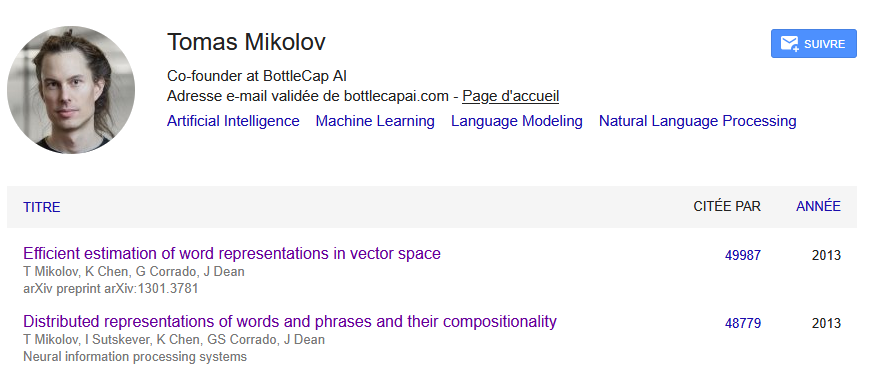

- Vectors are trained on a predicting task:
  - Next token, masked tokens ;
  - The vector values are the learned weights of a neural network.

## Contextual embeddings

Figure 5: A simplified representation of words embeddings in 2D

[figure not shown]

- The distance between vectors reflects semantic similarity.
- Distance metric: cosine similarity.
- First models: fixed embeddings (e.g., word2vec, GloVe).
- LLMs: contextual embeddings (e.g., BERT, GPT, etc.).

## Sentence embeddings

We use sentence-BERT, a fast LLM model that reprensents **sentences** as vectors and is optimized for semantic similarity tasks.

Table 4: Closest to ‘Economic agents are supposed to be rational.’

| year | sentence | similarity |
| --- | --- | --- |
| 1950 | Basically, for Professor Hicks, as for Jevons and Marshall, economic decisions are made by an abstract calculating machine. | 0.706 |
| 1950 | Modern civilization is lopsided in its emphasis on rationality, especially on economic rationality. | 0.700 |
| 1950 | Rational behavior means conduct motivated by the goal of maximization of money income, wealth and economic advantages. | 0.700 |
| 1975 | Rationality and Irrationality in Economics. | 0.750 |
| 1975 | Such agents are assumed to act rationally and exclusively on the basis of market given information. | 0.721 |
| 1975 | In Marshallian analysis, economic agents are conceived to be not so much rational as reasonable. | 0.710 |
| 2000 | Agents have rational expectations. | 0.771 |
| 2000 | Rational in the narrow economic sense of profit maximizing. | 0.768 |
| 2000 | Actors who operate in an economy are generally rational in the sense that they are interested in improving their individual position. | 0.768 |

## Our empirical strategy

1. Compute a “representative vectors” for the concept of rationality.
   1. Select all sentences containing the words “rational” or “rationality”.
   2. Compute their sentence embeddings.
   3. We compute a moving average of those vectors over time.

Output: a “representative vector” for each year.

## Our empirical strategy

2. Retrieve the most similar sentences in the corpus from this vector.
   2. For each year, compute the cosine similarity between the “representative vector” and the 32M sentence embeddings in the corpus.
   3. Select the top 1% most similar sentences for each year.

Output: a set of sentences related to rationality for each year.

Sentences do not necessarily contain the words “rational” or “rationality”.

## Our empirical strategy

3. Group those sentences into clusters.
   3. Group sentences by decade using k-means.
   4. Compute clusters centroids.
   5. Merge similar clusters across adjacent decades.

Output: intertemporal clusters of sentences related to rationality.

## The alluvial diagram of intertemporal clusters

[figure not shown]

## Navigating our own results with an app

https://0199205a-7b17-ab11-595d-8f12aae160dd.share.connect.posit.cloud/

## Conclusion

- LLMs offers a tool to quantify conceptual relationship betweens texts.

**But important challenges:**

- Existing models are trained for understanding general language, not economic discourses.
- Model are present-centric.
- Computational ressources.
- Data access (Elsevier, Taylor and Francis, Books, *etc*.).